# Lab 2: Analisi descrittive

Analisi dei Dati 2023-24

Cristiano Varin

# 1 Sintesi numeriche

Iniziamo utilizzando i dati sui tempi di elaborazione dei processi presentati nel Capitolo 8 del Baron (2014).

Leggiamo i dati:

```r
cpu <- scan("CPU-times.txt")
cpu
```

```
##  [1]  70  36  43  69  82  48  34  62  35  15  59 139  46  37  42  30  55  56  36
## [20]  82  38  89  54  25  35  24  22   9  56  19
```

Calcoliamo la media:

```r
mean(cpu)
```

```
## [1] 48.23333
```

La mediana:

```r
median(cpu)
```

```
## [1] 42.5
```

Il primo, il secondo e il terzo quartile, che corrispondono ai quantili di ordine 0.25, 0.5 e 0.75:

```r
## primo quartile
quantile(cpu, probs = 0.25, type = 2)
```

```
## 25%
##  34
```

```r
## secondo quartile
quantile(cpu, probs = 0.5, type = 2)
```

```
##  50%
## 42.5
```

```r
## terzo quartile
quantile(cpu, probs = 0.75, type = 2)
```

```
## 75%
##  59
```

L’argomento `type = 2` nella funzione **quantile** è necessario per calcolare i quantili in modo coerente con il libro di testo Baron (2014). Esistono infatti diversi algoritmi per calcolare i quantili e quello usato di default da **R** porta a risultati diversi, come potete vedere di seguito:

```r
## primo quartile, calcolo di default
quantile(cpu, probs = 0.25)
```

```
##   25%
## 34.25
```

```r
## secondo quartile, calcolo di default
quantile(cpu, probs = 0.5)
```

```
##  50%
## 42.5
```

```r
## terzo quartile, calcolo di default
quantile(cpu, probs = 0.75)
```

```
##   75%
## 58.25
```

La varianza:

```r
var(cpu)
```

```
## [1] 703.1506
```

```r
## verifica
sum((cpu - mean(cpu)) ^ 2) / (length(cpu) - 1)
```

```
## [1] 703.1506
```

La deviazione standard:

```r
sd(cpu)
```

```
## [1] 26.51699
```

Lo scarto interquartile:

```r
Q1 <- quantile(cpu, probs = 0.25, type = 2)
Q3 <- quantile(cpu, probs = 0.75, type = 2)
Q3 - Q1
```

```
## 75%
##  25
```

```r
## o direttamente con la funzione IQR
IQR(cpu, type = 2)
```

```
## [1] 25
```

# 2 Sintesi grafiche

Nella seconda sezione utilizzando sempre i dati presentati nel Capitolo 8 del Baron (2014) per mostrare come disegnare alcuni grafici di base con **R**.

## 2.1 Istogrammi

La funzione `hist` disegna di *default* l’istogramma delle frequenza (assolute):

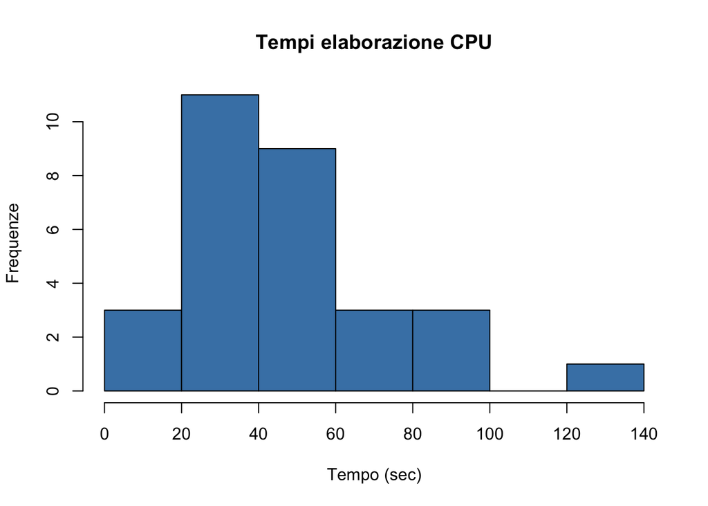

```r
isto <- hist(cpu, main = "Tempi elaborazione CPU", xlab = "Tempo (sec)",
ylab = "Frequenze", col = "steelblue")
```

Il comando precedente ha salvato l’istogramma nell’oggetto `isto` per esplorare le sue componenti:

```r
names(isto)
```

```
## [1] "breaks"   "counts"   "density"  "mids"     "xname"    "equidist"
```

Le componenti dell’oggetto `isto` possono essere estratte con l’operatore `$`:

```r
## osservazioni per intervallo
isto$counts
```

```
## [1]  3 11  9  3  3  0  1
```

```r
## intervalli (breaks)
isto$breaks
```

```
## [1]   0  20  40  60  80 100 120 140
```

L’istogramma è stato disegnato con il colore `steelblue` che verrà usato molto spesso nei grafici di questo corso. Se volete variare i colori dei vostri grafici potete consultare questa guida: http://www.stat.columbia.edu/~tzheng/files/Rcolor.pdf.

Per ottenere l’istogramma delle densità bisogna usare l’opzione `freq = FALSE`:

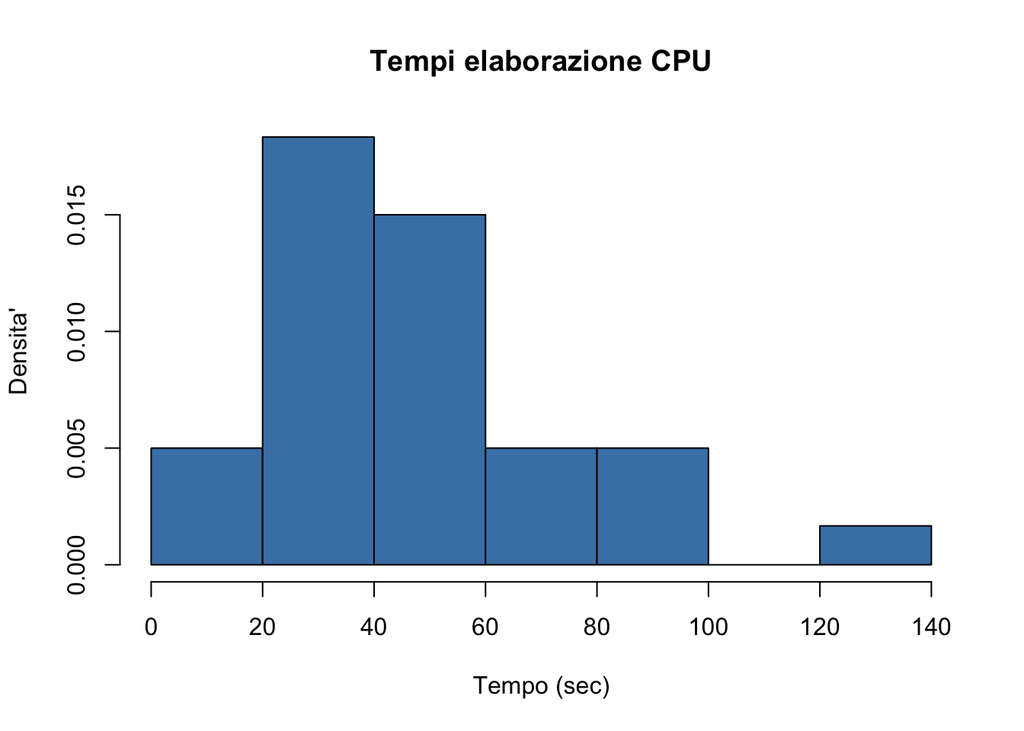

```r
isto <- hist(cpu, freq = FALSE, main = "Tempi elaborazione CPU", xlab = "Tempo (sec)", ylab = "Densita'", col = "steelblue")
```

Le densità che appaiono nell’istogramma sono:

```r
isto$density
```

```
## [1] 0.005000000 0.018333333 0.015000000 0.005000000 0.005000000 0.000000000
## [7] 0.001666667
```

Le densità sono pari alle frequenze relative divise per la dimensione degli intervalli:

```r
freqrel <- isto$counts / sum(isto$counts)
freqrel / 20
```

```
## [1] 0.005000000 0.018333333 0.015000000 0.005000000 0.005000000 0.000000000
## [7] 0.001666667
```

Dividere per la dimensione degli intervalli è importante se gli intervalli hanno larghezze diverse.

L’opzione `breaks` permette, in principio, di modificare il numero di intervalli con cui è disegnato l’istogramma. In pratica, **R** prende l’indicazione fornita con `breaks` come un suggerimento e sceglie un numero di intervalli vicino che soddisfi delle regole interne:

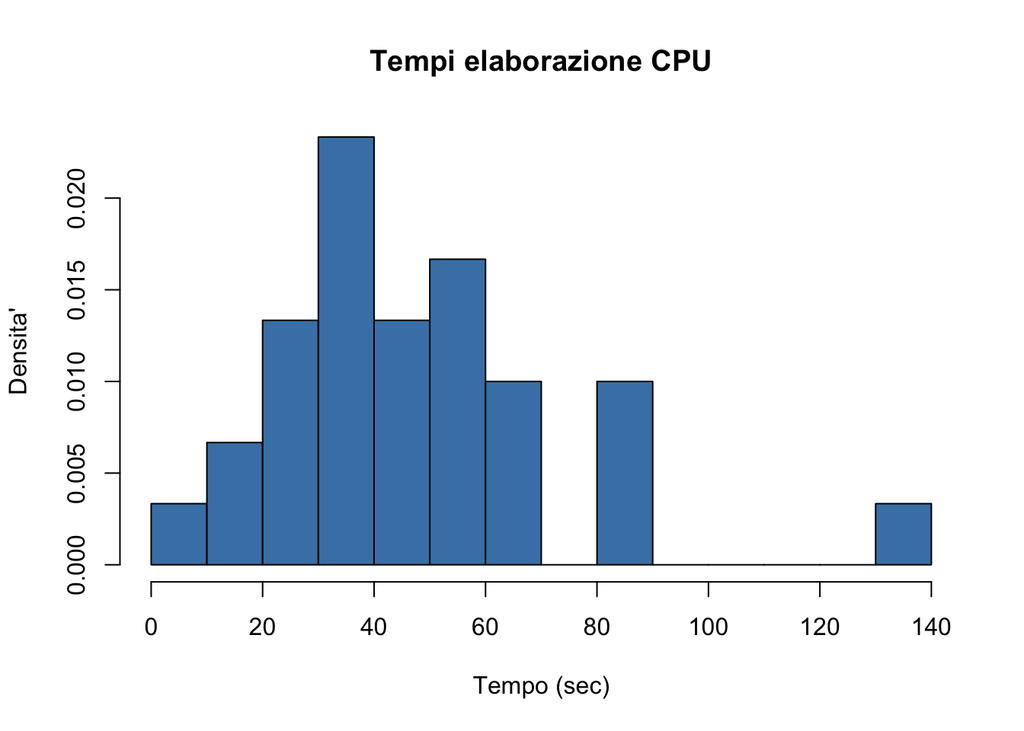

```r
isto <- hist(cpu, freq = FALSE, main = "Tempi elaborazione CPU", xlab = "Tempo (sec)", ylab = "Densita'", col = "steelblue", breaks = 12)
```

Vediamo quanti intervalli sono stati, effettivamente, calcolati da `hist`:

```r
isto$breaks
```

```
##  [1]   0  10  20  30  40  50  60  70  80  90 100 110 120 130 140
```

```r
length(isto$breaks)
```

```
## [1] 15
```

Spesso è utile sovrapporre all’istogramma una stima della funzione di densità calcolata con la funzione `density`:

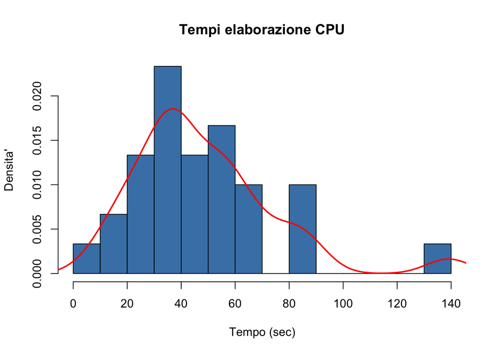

```r
hist(cpu, freq = FALSE, main = "Tempi elaborazione CPU",  xlab = "Tempo (sec)", ylab = "Densita'", col = "steelblue", breaks = 12)
lines(density(cpu), col = "red", lwd = 2) ## linea con spessore doppio (lwd = 2)
```

## 2.2 Grafici a scatola (boxplot)

Il boxplot dei tempi di elaborazione si può disegnare con la funzione `boxplot`:

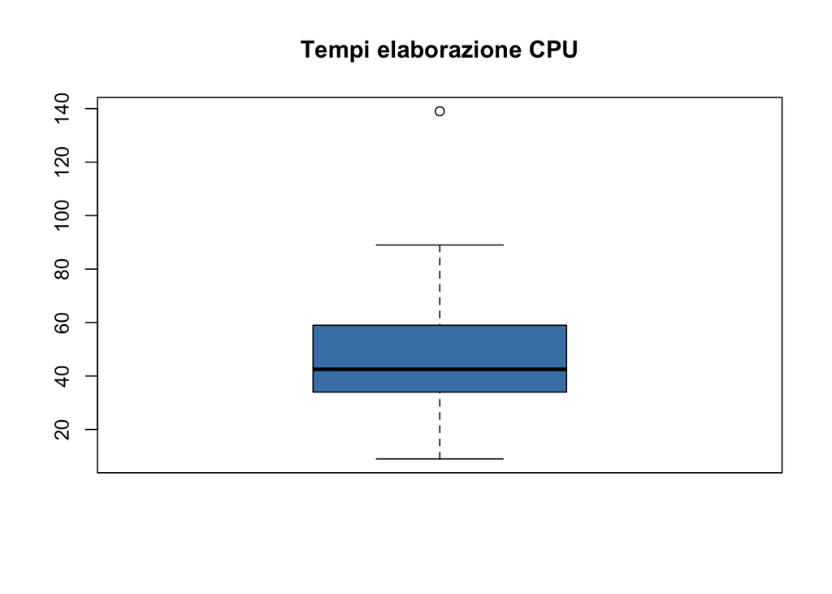

```r
bp <- boxplot(cpu, main = "Tempi elaborazione CPU", col = "steelblue")
```

Le statistiche utilizzate per disegnare il boxplot si possono ottenere con la funzione `summary`:

```r
summary(cpu)
```

```
##    Min. 1st Qu.  Median    Mean 3rd Qu.    Max.
##    9.00   34.25   42.50   48.23   58.25  139.00
```

In realtà, però, le statistiche usate dalla funzione `boxplot` sono leggermente diverse:

```r
bp$stats
```

```
##      [,1]
## [1,]  9.0
## [2,] 34.0
## [3,] 42.5
## [4,] 59.0
## [5,] 89.0
```

Lo slot `stats` dell’oggetto `bp` contiene, nell’ordine, il “baffo” inferiore, il primo quartile, la mediana, il terzo quartile, il “baffo” superiore. Il baffo superiore si ferma a 89 poiché il boxplot non disegna punti oltre il seguente limite:

```r
59 + 1.5 * (59 - 34)
```

```
## [1] 96.5
```

e l’osservazione più grande che non supera questo limite è appunto

```r
max(cpu[cpu <= 96.5])
```

```
## [1] 89
```

Quest’ultimo comando calcola il massimo fra tutti i tempi di elaborazione non superiori a 96.5. Per estrarre il sottoinsieme dei tempi non superiori a 96.5 è stato usato l’operatore `[]`.

Possiamo aggiungere al boxplot la media dei tempi di elaborazione con la funzione `points`:

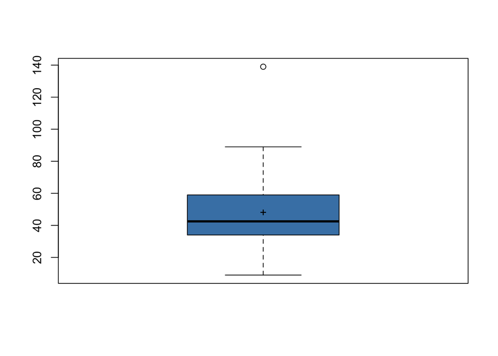

```r
boxplot(cpu, col = "steelblue")
points(mean(cpu), pch = "+") ## pch significa "point character"
```

Il file **CPU-times-2.txt** contiene un secondo campione di tempi di elaborazione:

```r
cpu2 <- scan("CPU-times-2.txt")
```

Possiamo confrontare visivamente i due campioni attraverso due boxplot appaiati:

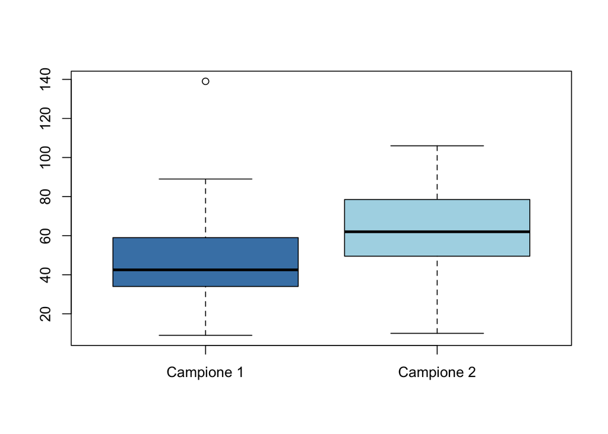

```r
boxplot(cpu, cpu2, col = c("steelblue", "lightblue"), names = c("Campione 1", "Campione 2"))
```

Nell’ultima chiamata a `boxplot` abbiamo usato la funzione `c` (“combine”) per creare un vettore di due colori, `c("steelblue", "lightblue")`, e un vettore di due etichette, `c("campione 1", "campione 2")`.

## 2.3 Grafici a dispersione

Il file **antivirus.csv** contiene i dati discussi nel capitolo 8 del Baron (2014) sulla relazione fra l’utilizzo degli antivirus nell’ultimo mese e i virus (*worms*) individuati. Possiamo importare i dati in **R** con la funzione `read.csv`:

```r
antivirus <- read.csv("antivirus.csv")
antivirus
```

| x | y |
| --- | --- |
| 30 | 0 |
| 30 | 0 |
| 30 | 1 |
| 30 | 0 |
| 30 | 0 |
| 30 | 0 |
| 30 | 1 |
| 30 | 1 |
| 30 | 0 |
| 30 | 0 |

[output cut: 20 more lines]

Grafico a dispersione del numero di *worms* in funzione del numero di volte che l’antivirus è stato eseguito nell’ultimo mese:

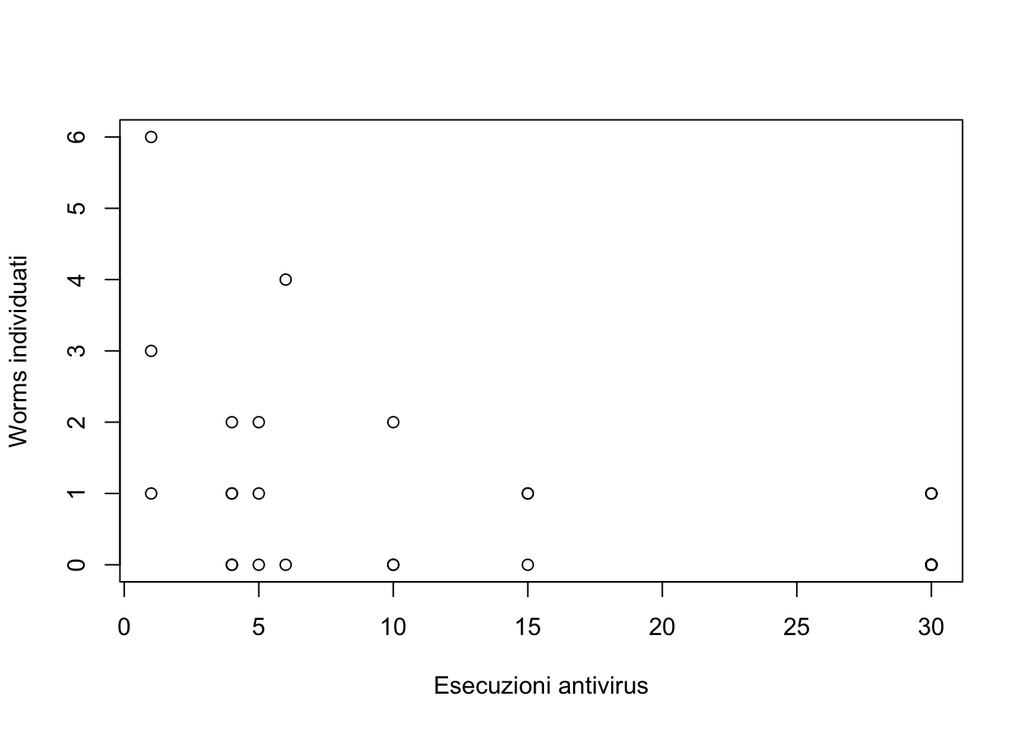

```r
with(antivirus, plot(x, y, xlab = "Esecuzioni antivirus", ylab = "Worms individuati"))
```

Siccome ci sono molte osservazioni ripetute il grafico non coglie davvero la struttura dei dati. Possiamo ovviare a questo problema aggiungendo un piccola quantità di errore casuale ad ogni osservazione con la funzione `jitter` (“agitato”):

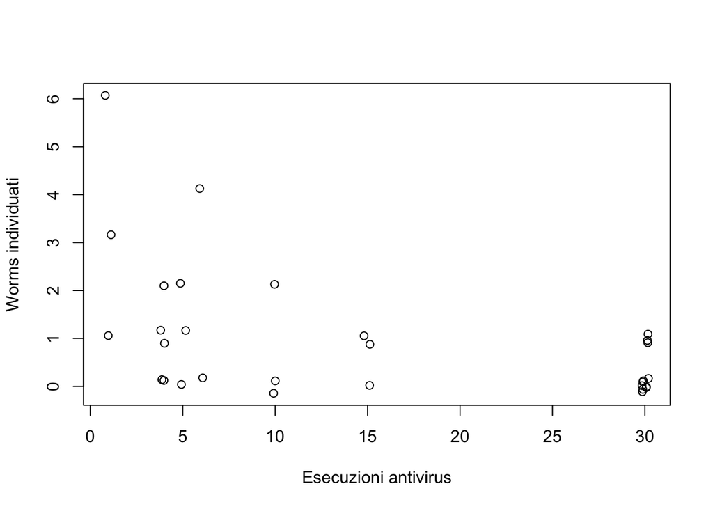

```r
with(antivirus, plot(jitter(x), jitter(y), xlab = "Esecuzioni antivirus", ylab = "Worms individuati"))
```

# 3 I prezzi delle case

In questa terza sezione vengono illustrate le analisi esplorative di base su un campione di dati del mercato immobiliare di una città americana. I dati, contenuti nel file **HousePrice.csv**[^1], comprendono le seguenti informazioni:

- `Price` prezzo dell’abitazione in dollari americani;
- `SqFt` dimensione dell’abitazione in piedi quadri;
- `Bedrooms` numero di stanze da letto;
- `Bathrooms` numero di stanze da bagno;
- `Offers` numero di offerte che ha ricevuto l’abitazione da quando è stata messa sul mercato;
- `Brick` indicatore se l’abitazione ha i muri in mattone;
- `Neighborhood` il quartiere dove si trova l’abitazione: `East`, `West` o `North`.

Leggiamo i dati con la funzione `read.csv`:

```r
house <- read.csv("HousePrices.csv")
```

Qualche informazione di partenza sui dati:

```r
## dimensione del dataset
dim(house)
```

```
## [1] 128   8
```

```r
## numero di righe, numero di colonne
nrow(house)
```

```
## [1] 128
```

```r
ncol(house)
```

```
## [1] 8
```

```r
## prime righe del dataset
head(house)
```

|  | HomeID | Price | SqFt | Bedrooms | Bathrooms | Offers | Brick | Neighborhood |
| --- | --- | --- | --- | --- | --- | --- | --- | --- |
| 1 | 1 | 114300 | 1790 | 2 | 2 | 2 | No | East |
| 2 | 2 | 114200 | 2030 | 4 | 2 | 3 | No | East |
| 3 | 3 | 114800 | 1740 | 3 | 2 | 1 | No | East |
| 4 | 4 | 94700 | 1980 | 3 | 2 | 3 | No | East |
| 5 | 5 | 119800 | 2130 | 3 | 3 | 3 | No | East |
| 6 | 6 | 114600 | 1780 | 3 | 2 | 2 | No | North |

```r
## un po' di piu'...
head(house, 10)
```

|  | HomeID | Price | SqFt | Bedrooms | Bathrooms | Offers | Brick | Neighborhood |
| --- | --- | --- | --- | --- | --- | --- | --- | --- |
| 1 | 1 | 114300 | 1790 | 2 | 2 | 2 | No | East |
| 2 | 2 | 114200 | 2030 | 4 | 2 | 3 | No | East |
| 3 | 3 | 114800 | 1740 | 3 | 2 | 1 | No | East |
| 4 | 4 | 94700 | 1980 | 3 | 2 | 3 | No | East |
| 5 | 5 | 119800 | 2130 | 3 | 3 | 3 | No | East |
| 6 | 6 | 114600 | 1780 | 3 | 2 | 2 | No | North |
| 7 | 7 | 151600 | 1830 | 3 | 3 | 3 | Yes | West |
| 8 | 8 | 150700 | 2160 | 4 | 2 | 2 | No | West |
| 9 | 9 | 119200 | 2110 | 4 | 2 | 3 | No | East |
| 10 | 10 | 104000 | 1730 | 3 | 3 | 3 | No | East |

```r
## ultime righe
tail(house)
```

|  | HomeID | Price | SqFt | Bedrooms | Bathrooms | Offers | Brick | Neighborhood |
| --- | --- | --- | --- | --- | --- | --- | --- | --- |
| 123 | 123 | 144800 | 2060 | 2 | 2 | 1 | Yes | East |
| 124 | 124 | 119700 | 1900 | 3 | 3 | 3 | Yes | East |
| 125 | 125 | 147900 | 2160 | 4 | 3 | 3 | Yes | East |
| 126 | 126 | 113500 | 2070 | 2 | 2 | 2 | No | North |
| 127 | 127 | 149900 | 2020 | 3 | 3 | 1 | No | West |
| 128 | 128 | 124600 | 2250 | 3 | 3 | 4 | No | North |

```r
## nomi delle colonne
names(house)
```

```
## [1] "HomeID"       "Price"        "SqFt"         "Bedrooms"     "Bathrooms"
## [6] "Offers"       "Brick"        "Neighborhood"
```

Se avete bisogno di più dettagli sulla sintassi di un commando **R**, potete invocare la guida in linea:

```r
help("tail")
## oppure
?"tail"
```

Come di consuetudine in statistica, le righe del dataset corrispondono alle diverse unità statistiche, ovvero nel caso specifico le abitazioni, mentre le colonne corrispondono alle variabili osservate sulle unità.

Per estrarre il prezzo della ventesima abitazione si può utilizzare l’operatore `[]` specificando l’unità (riga 20) e la variabile (colonna 2):

```r
house[20, 2]
```

```
## [1] 167200
```

oppure dichiarando esplicitamente la variabile di interesse:

```r
house[20, "Price"]
```

```
## [1] 167200
```

Per estrarre tutte le informazioni relative alla ventesima abitazione bisogna indicare esclusivamente la riga 20:

```r
house[20, ]
```

|  | HomeID | Price | SqFt | Bedrooms | Bathrooms | Offers | Brick | Neighborhood |
| --- | --- | --- | --- | --- | --- | --- | --- | --- |
| 20 | 20 | 167200 | 1920 | 3 | 3 | 2 | Yes | West |

Per estrarre invece tutte le osservazioni relative alla variabile `Price` che corrisponde alla seconda colonna si indica esclusivamente la colonna 2:

```r
head(house[, 2])
```

```
## [1] 114300 114200 114800  94700 119800 114600
```

oppure usando il nome della variabile:

```r
head(house[, "Price"])
```

```
## [1] 114300 114200 114800  94700 119800 114600
```

o ancora con l’operatore `$`:

```r
head(house$Price)
```

```
## [1] 114300 114200 114800  94700 119800 114600
```

Usiamo ora la funzione `summary` per riassumere il dataset:

```r
summary(house)
```

```
##      HomeID           Price             SqFt         Bedrooms
##  Min.   :  1.00   Min.   : 69100   Min.   :1450   Min.   :2.000
##  1st Qu.: 32.75   1st Qu.:111325   1st Qu.:1880   1st Qu.:3.000
##  Median : 64.50   Median :125950   Median :2000   Median :3.000
##  Mean   : 64.50   Mean   :130427   Mean   :2001   Mean   :3.023
##  3rd Qu.: 96.25   3rd Qu.:148250   3rd Qu.:2140   3rd Qu.:3.000
##  Max.   :128.00   Max.   :211200   Max.   :2590   Max.   :5.000
##    Bathrooms         Offers         Brick           Neighborhood
##  Min.   :2.000   Min.   :1.000   Length:128         Length:128
##  1st Qu.:2.000   1st Qu.:2.000   Class :character   Class :character
##  Median :2.000   Median :3.000   Mode  :character   Mode  :character
##  Mean   :2.445   Mean   :2.578
##  3rd Qu.:3.000   3rd Qu.:3.000
##  Max.   :4.000   Max.   :6.000
```

L’output della funzione `summary` evidenzia che il dataset contiene sei variabili numeriche (`HomeID`, `Price`, `SqFt`, `Bedrooms`, `Bathrooms`, `Offers`) e due variabili categoriali (`Brick` e `Neighborhood`).

I “riassunti” delle variabili numeriche riportano il minimo, il massimo, i quartili e la media. Le due variabili categoriali sono state lette come stringhe di caratteri (`Class: character`) ma per le analisi successive è meglio codificarle come variabili categoriali con la funzione `factor`:

```r
house$Brick <- factor(house$Brick)
house$Neighborhood <- factor(house$Neighborhood)
```

Vediamo nuovamente il riassunto del dataset dopo la ricodifica delle variabili categoriali:

```r
summary(house)
```

```
##      HomeID           Price             SqFt         Bedrooms
##  Min.   :  1.00   Min.   : 69100   Min.   :1450   Min.   :2.000
##  1st Qu.: 32.75   1st Qu.:111325   1st Qu.:1880   1st Qu.:3.000
##  Median : 64.50   Median :125950   Median :2000   Median :3.000
##  Mean   : 64.50   Mean   :130427   Mean   :2001   Mean   :3.023
##  3rd Qu.: 96.25   3rd Qu.:148250   3rd Qu.:2140   3rd Qu.:3.000
##  Max.   :128.00   Max.   :211200   Max.   :2590   Max.   :5.000
##    Bathrooms         Offers      Brick    Neighborhood
##  Min.   :2.000   Min.   :1.000   No :86   East :45
##  1st Qu.:2.000   1st Qu.:2.000   Yes:42   North:44
##  Median :2.000   Median :3.000            West :39
##  Mean   :2.445   Mean   :2.578
##  3rd Qu.:3.000   3rd Qu.:3.000
##  Max.   :4.000   Max.   :6.000
```

L’output di `summary` ora riporta la distribuzione di frequenza per le variabili categoriali, ovvero la frequenza con la quale sono osservati i diversi livelli delle variabili categoriali: `No` e `Yes` per `Brick`; `East`, `North` e `West` per `Neighborhood`.

Avremmo potuto evitare di dover covertire `Brick` e `Neighborhood` to `factors` leggendo i dati con la funzione `read.csv` con l’opzione `stringsAsFactors = TRUE`:

```r
prova <- read.csv("HousePrices.csv", stringsAsFactors = TRUE)
summary(prova)
```

```
##      HomeID           Price             SqFt         Bedrooms
##  Min.   :  1.00   Min.   : 69100   Min.   :1450   Min.   :2.000
##  1st Qu.: 32.75   1st Qu.:111325   1st Qu.:1880   1st Qu.:3.000
##  Median : 64.50   Median :125950   Median :2000   Median :3.000
##  Mean   : 64.50   Mean   :130427   Mean   :2001   Mean   :3.023
##  3rd Qu.: 96.25   3rd Qu.:148250   3rd Qu.:2140   3rd Qu.:3.000
##  Max.   :128.00   Max.   :211200   Max.   :2590   Max.   :5.000
##    Bathrooms         Offers      Brick    Neighborhood
##  Min.   :2.000   Min.   :1.000   No :86   East :45
##  1st Qu.:2.000   1st Qu.:2.000   Yes:42   North:44
##  Median :2.000   Median :3.000            West :39
##  Mean   :2.445   Mean   :2.578
##  3rd Qu.:3.000   3rd Qu.:3.000
##  Max.   :4.000   Max.   :6.000
```

Possiamo usare `summary` per riassumere separatamente ogni singola variabile, per esempio `Price`:

```r
with(house, summary(Price))
```

```
##    Min. 1st Qu.  Median    Mean 3rd Qu.    Max.
##   69100  111325  125950  130427  148250  211200
```

Disegniamo l’istogramma di `Price`:

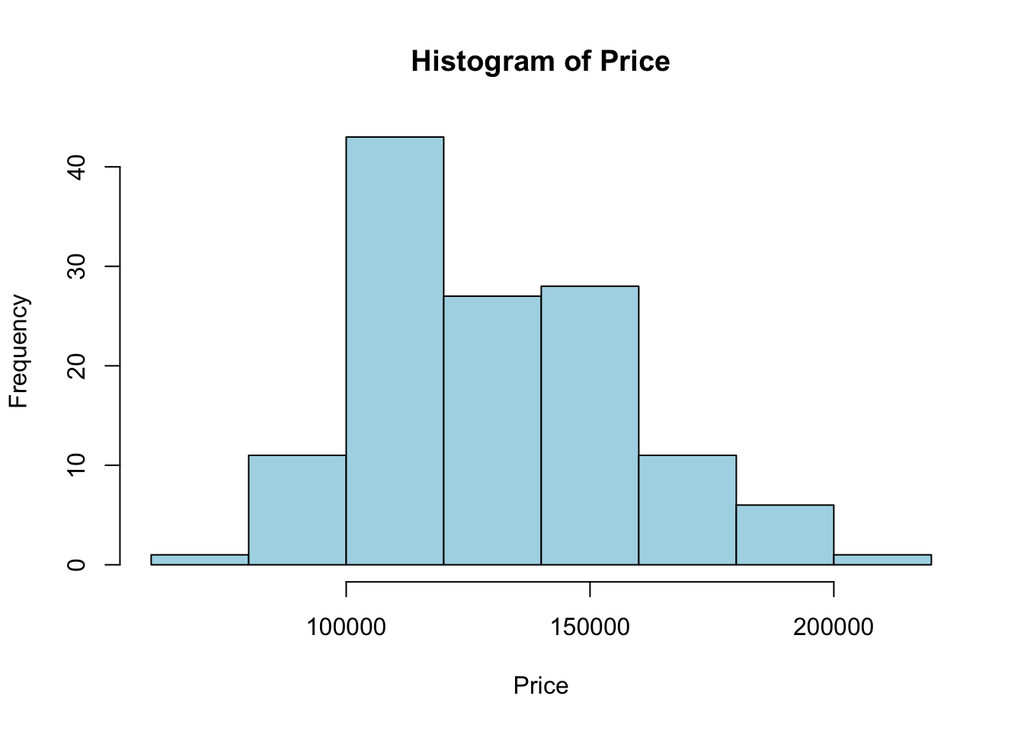

```r
with(house, hist(Price, col = "lightblue"))
```

e il boxplot di `Price`:

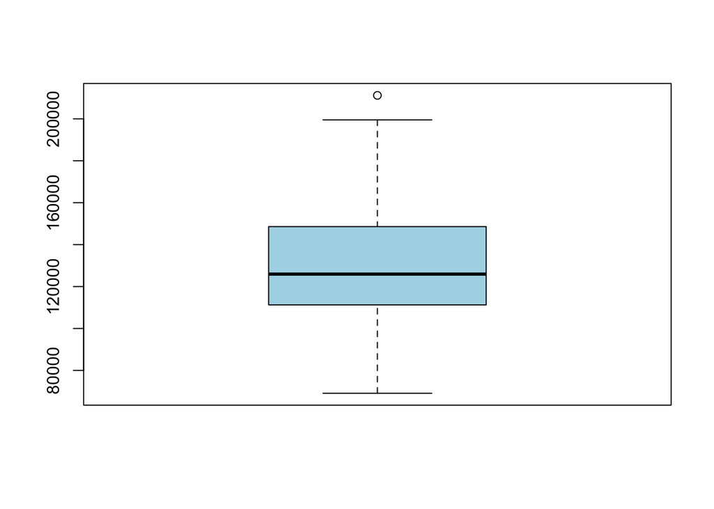

```r
with(house, boxplot(Price, col = "lightblue"))
```

Ora istogramma e boxplot di `Price` nello stesso grafico:

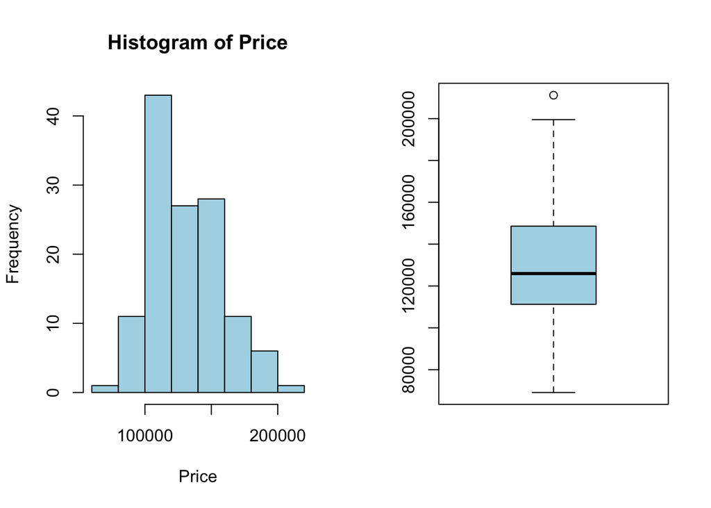

```r
## per prima cosa suddividiamo la finestra grafica in 1 riga e 2 colonne
par(mfrow = c(1, 2))
## e quindi
with(house, hist(Price, col = "lightblue"))
with(house, boxplot(Price, col = "lightblue"))
```

```r
## torniamo alla finestra grafica non suddivisa
par(mfrow = c(1, 1))
```

Calcoliamo la covarianza fra `Price` e `SqFt`:

```r
with(house, cov(Price, SqFt))
```

```
## [1] 3143533
```

```r
## verifica
with(house, sum((Price - mean(Price)) * (SqFt - mean(SqFt))) / (nrow(house) - 1))
```

```
## [1] 3143533
```

e la correlazione fra `Price` e `SqFt`:

```r
with(house, cor(Price, SqFt))
```

```
## [1] 0.5529822
```

Possiamo controllare il numero di cifre significative della correlazione con la funzione `signif`:

```r
with(house, signif(cor(Price, SqFt), digits = 2))
```

```
## [1] 0.55
```

Ora disegniamo il grafico a dispersione di `Price` rispetto a `SqFt` per visualizzare la relazione crescente fra prezzo e dimensione dell’abitazione:

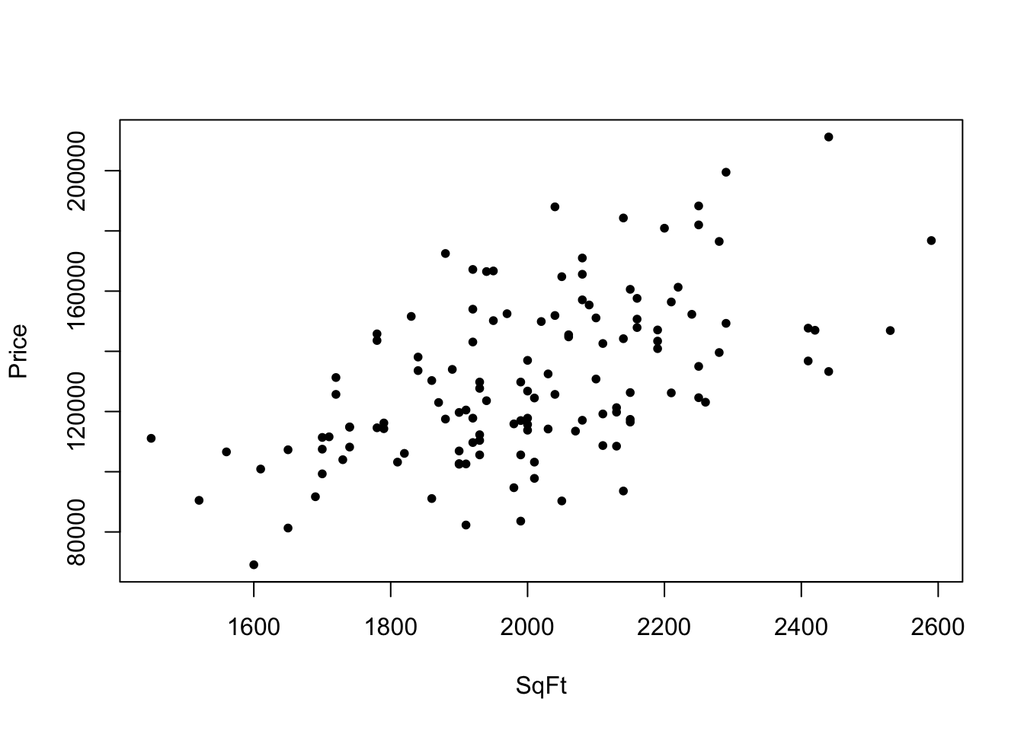

```r
plot(Price ~ SqFt, data = house, pch = 20)
```

Vediamo ora il riassunto di `Bedrooms`:

```r
with(house, summary(Bedrooms))
```

```
##    Min. 1st Qu.  Median    Mean 3rd Qu.    Max.
##   2.000   3.000   3.000   3.023   3.000   5.000
```

Il boxplot di `Bedrooms` non è molto informativo…

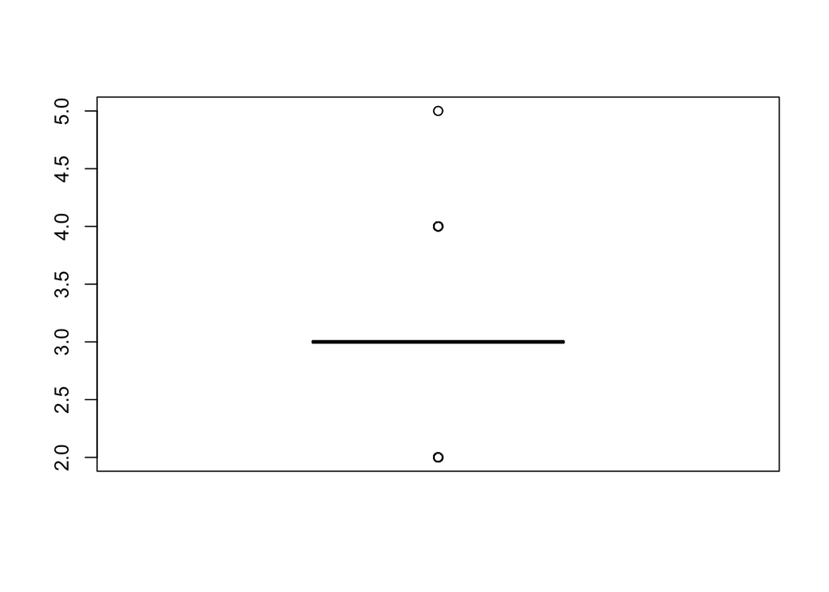

```r
with(house, boxplot(Bedrooms, col = "lightblue"))
```

Siccome `Bedrooms` presenta solo quattro possibili valori, allora la sua distribuzione può essere più efficacemente riassunta da una tabella di frequenza:

```r
with(house, table(Bedrooms))
```

```
## Bedrooms
##  2  3  4  5
## 30 67 29  2
```

oppure usando le frequenze relative:

```r
tab.bed <- with(house, prop.table(table(Bedrooms)))
tab.bed
```

```
## Bedrooms
##         2         3         4         5
## 0.2343750 0.5234375 0.2265625 0.0156250
```

La distribuzione di `Bedrooms` può essere rappresentata con un grafico a barre:

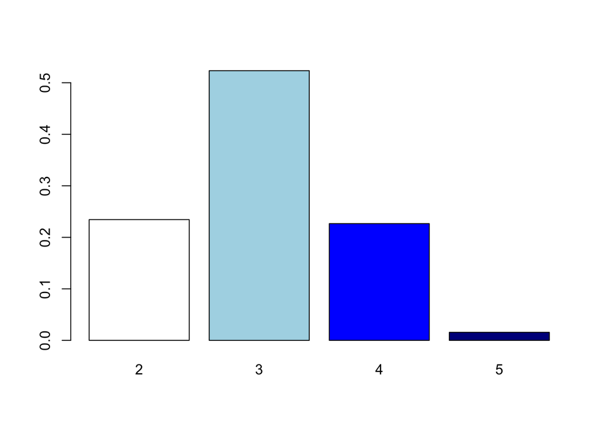

```r
with(house, barplot(tab.bed, col = c("white", "lightblue", "blue", "darkblue")))
```

La distribuzione di `Price` condizionatamente a `Bedrooms` può essere rappresentata con dei boxplot appaiati:

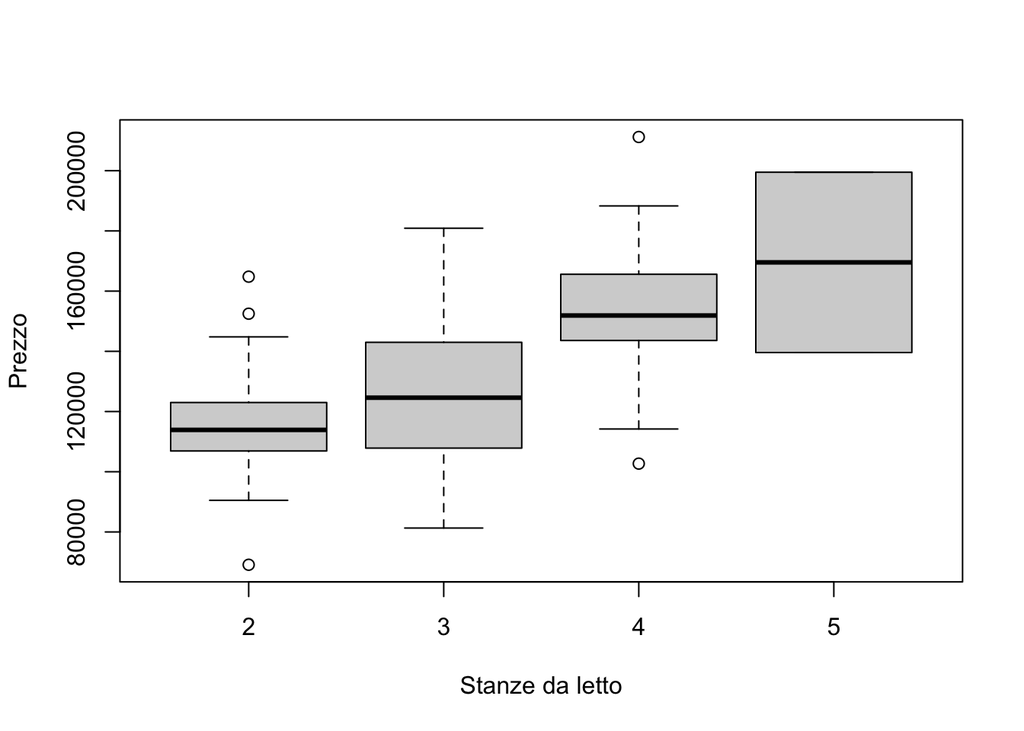

```r
boxplot(Price ~ Bedrooms, data = house, xlab = "Stanze da letto", ylab = "Prezzo")
```

Possiamo migliorare l’estetica del grafico precedente usando le tavolozze di colori (*color palettes*) disponibili con il pacchetto opzionale **RColorBrewer**. Per prima cosa dobbiamo caricare il pacchetto:

```r
## installiamo il pacchetto (solo la prima volta!)
install.packages("RColorBrewer")
## carichiamo il pacchetto
library("RColorBrewer")
```

Ora disegniamo i boxplot appaiati con una tavolozza blu:

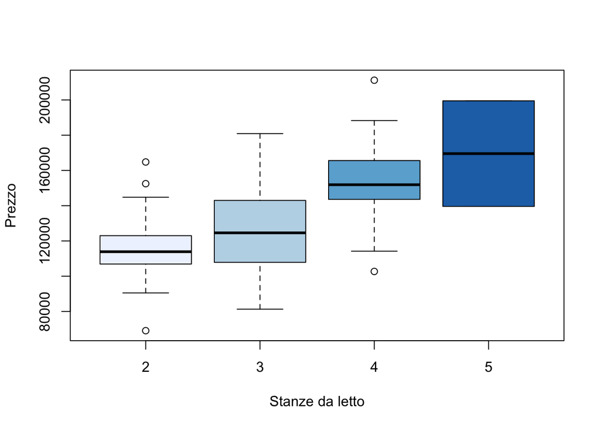

```r
boxplot(Price ~ Bedrooms, data = house, col = brewer.pal(4, "Blues"), xlab = "Stanze da letto", ylab = "Prezzo")
```

Calcoliamo la correlazione fra `Price` e `Bedrooms`:

```r
with(house, cor(Price, Bedrooms))
```

```
## [1] 0.5259261
```

Passiamo ora alla variabile categoriale `Neighborhood`:

```r
with(house, summary(Neighborhood))
```

```
##  East North  West
##    45    44    39
```

Non ha ovviamente senso calcolare la media, la mediana o qualsiasi altra sintesi numerica per `Neighborhood`:

```r
mean(house$Neighborhood)
```

```
## [1] NA
```

```r
median(house$Neighborhood)
```

```
## Error in median.default(house$Neighborhood): need numeric data
```

La distribuzione di frequenza di `Neighborhood` può essere visualizzata con un grafico a barre:

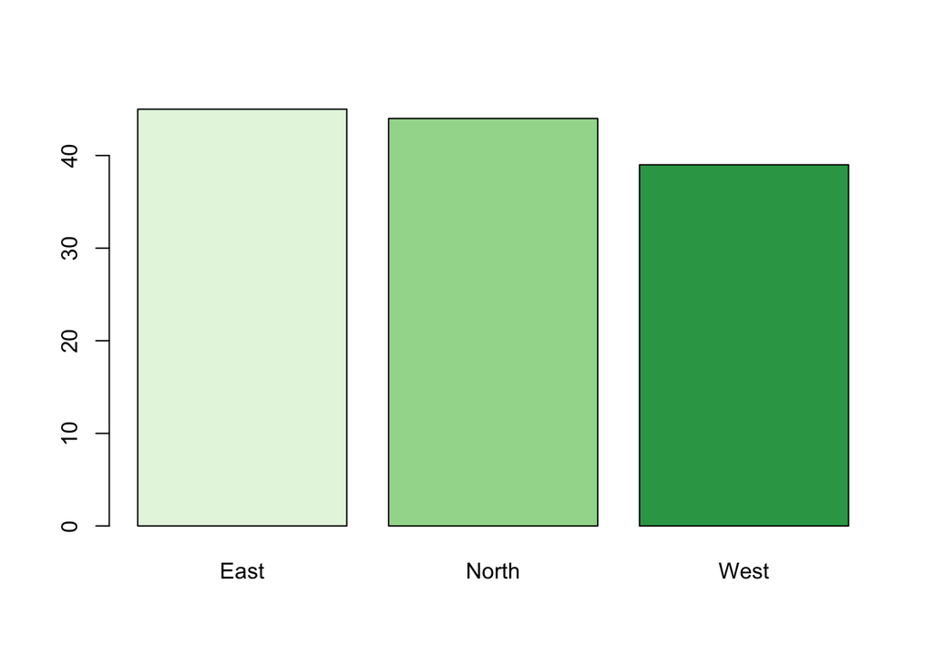

```r
with(house, plot(Neighborhood, col = brewer.pal(3, "Greens")))
```

La distribuzione di `Price` condizionatamente a `Neighborhood` può essere riassunta con la funzione `summary` applicata ai livelli di `Neighborhood` tramite la funzione `by`:

```r
with(house, by(Price, Neighborhood, summary))
```

```
## Neighborhood: East
##    Min. 1st Qu.  Median    Mean 3rd Qu.    Max.
##   82300  114300  123100  125231  139600  157100
## ------------------------------------------------------------
## Neighborhood: North
##    Min. 1st Qu.  Median    Mean 3rd Qu.    Max.
##   69100  102575  110750  110155  117575  150200
## ------------------------------------------------------------
## Neighborhood: West
##    Min. 1st Qu.  Median    Mean 3rd Qu.    Max.
##  129800  144850  155400  159295  171750  211200
```

Possiamo anche ottenere la distribuzione condizionata tramite l’operatore `[]`:

```r
## per esempio, i prezzi nel quartiere East
with(house, summary(Price[Neighborhood == "East"]))
```

```
##    Min. 1st Qu.  Median    Mean 3rd Qu.    Max.
##   82300  114300  123100  125231  139600  157100
```

Infine, disegniamo i boxplot di `Price` condizionatamente ai livelli di `Neighborhood`:

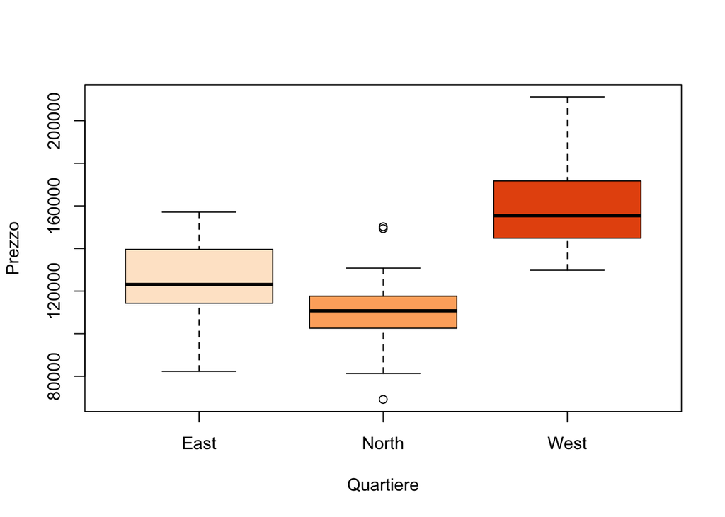

```r
boxplot(Price ~ Neighborhood, data = house, col = brewer.pal(3, "Oranges"), ylab = "Prezzo", xlab = "Quartiere")
```

# 4 I dipinti di Claude Monet

Nell’ultima sezione lavoriamo su un dataset che contiene il prezzo d’asta a cui sono stati battuti dei dipinti del celebre pittore impressionista Claude Monet.

Leggiamo i dati:

```r
monet <- read.csv("monet.csv")
```

Iniziamo con le statistiche descrittive di base del prezzo di vendita:

```r
summary(monet$price)
```

```
##     Min.  1st Qu.   Median     Mean  3rd Qu.     Max.
##  0.01041  0.60015  1.31278  3.09000  3.85000 33.01350
```

Il prezzo di vendita dei dipinti varia da 10 mila dollari a 33 milioni di dollari. Il prezzo di vendita medio è poco superiore ai 3 milioni di dollari, mentre il prezzo mediano è pari a 1,3 milioni di dollari. La differenza fra media e mediana indica che la distribuzione dei prezzi di vendita ha una asimmetria destra, come si vede nel seguente boxplot:

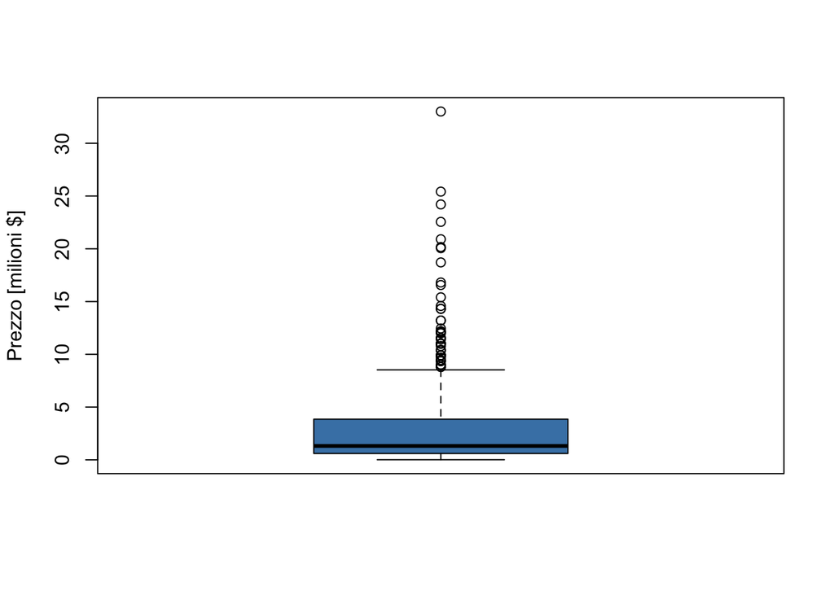

```r
with(monet, boxplot(price, col = "steelblue", ylab = "Prezzo [milioni $]"))
```

L’asimmetria può essere ampiamente ridotta considerando una trasformazione logartimica:

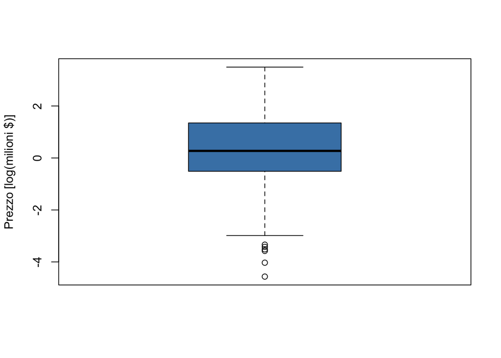

```r
with(monet, boxplot(log(price), col = "steelblue",
ylab = "Prezzo [log(milioni $)]"))
```

Vediamo come varia il prezzo di vendita del dipinto a seconda se sia o non sia firmato da Monet. Innanzitutto, notiamo che circa l’82% dei dipinti venduti sono firmati:

```r
table(monet$signed)
```

```
##
##   0   1
##  77 353
```

```r
## frequenze relative
prop.table(table(monet$signed))
```

```
##
##         0         1
## 0.1790698 0.8209302
```

```r
signif(prop.table(table(monet$signed)), digits = 2)
```

```
##
##    0    1
## 0.18 0.82
```

La distribuzione del prezzo di vendita condizionata alla firma mostra chiaramente che i dipinti firmati vengono venduti a prezzi decisamente superiori:

```r
with(monet, by(price, signed, summary))
```

```
## signed: 0
##     Min.  1st Qu.   Median     Mean  3rd Qu.     Max.
##  0.01041  0.19800  0.39917  1.83271  1.65575 16.80800
## ------------------------------------------------------------
## signed: 1
##     Min.  1st Qu.   Median     Mean  3rd Qu.     Max.
##  0.05351  0.72227  1.54250  3.36425  4.03950 33.01350
```

Il prezzo medio dei dipinti firmati è 3,3 milioni di dollari contro 1,8 per i dipinti non firmati, mentre i prezzi mediani sono 1,5 milioni di dollari per i dipinti firmati e 0,4 milioni di dollari per i dipinti non firmati.

I boxplot del prezzo di vendita condizionato alla firma risentono della forte asimmetricità della distribuzione dei prezzi:

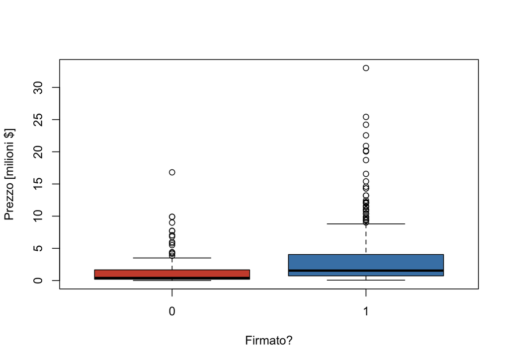

```r
with(monet, boxplot(price ~ signed, col = c("tomato3", "steelblue"),
xlab = "Firmato?", ylab = "Prezzo [milioni $]"))
```

Un confronto visivo più efficace si ottiene passando alla scala logaritmica:

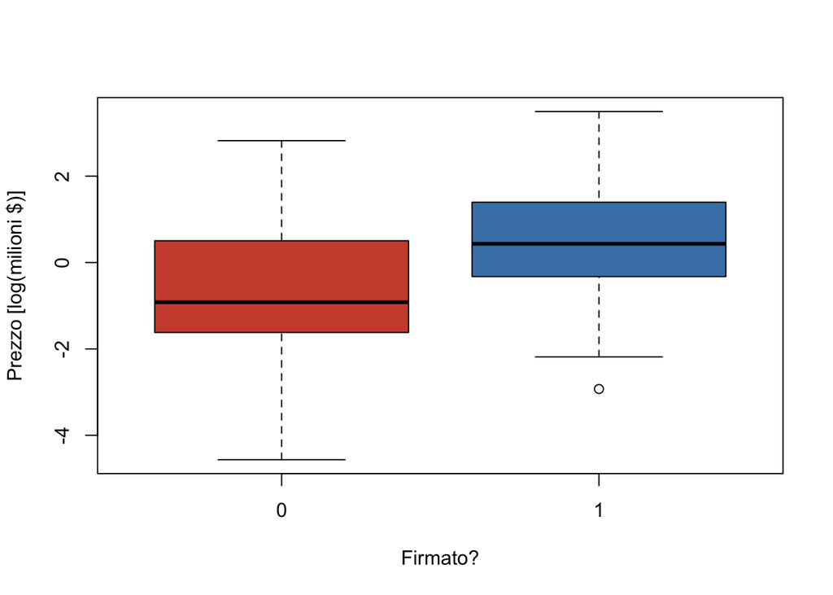

```r
with(monet, boxplot(log(price) ~ signed, col = c("tomato3", "steelblue"),
xlab = "Firmato?", ylab = "Prezzo [log(milioni $)]"))
```

La variabile `signed` può essere resa più espressiva modificando le etichette dei suoi livelli in modo che lo zero corrisponda a `No` e l’uno a `Sì`:

```r
## signed e' una variabile numerica
class(monet$signed)
```

```
## [1] "integer"
```

```r
## trasformazione in variabile categoriale
monet$signed <- factor(monet$signed)
## livelli di signed
levels(monet$signed)
```

```
## [1] "0" "1"
```

```r
## ricodifica dei livelli
levels(monet$signed) <- c("No", "Sì")
summary(monet$signed)
```

```
##  No  Sì
##  77 353
```

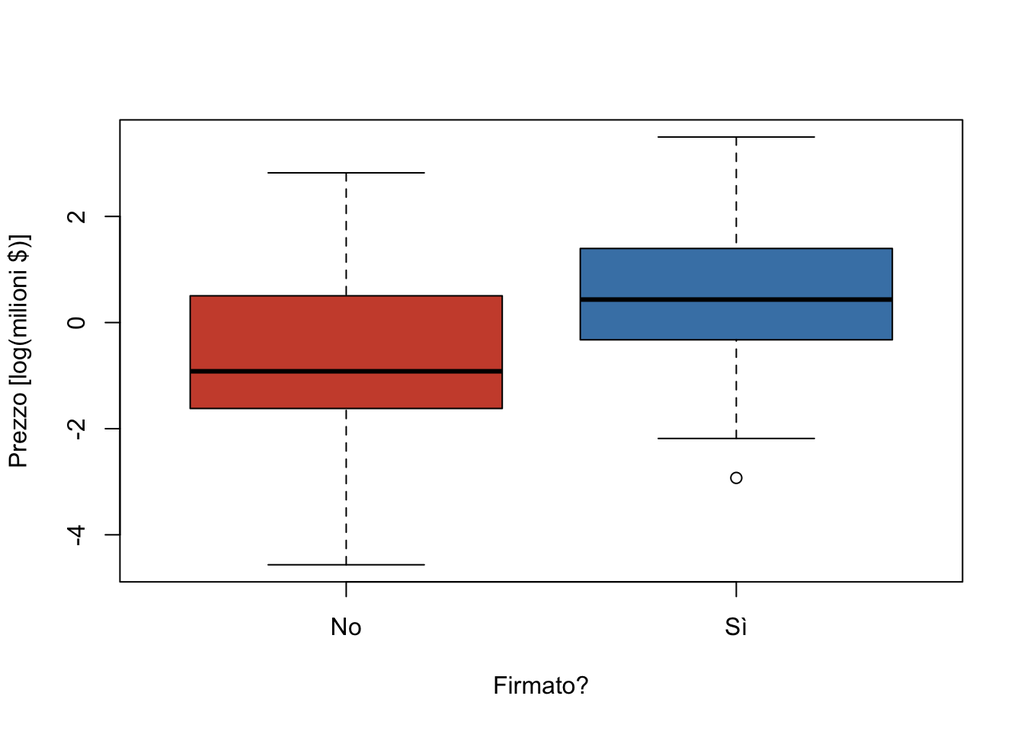

```r
with(monet, boxplot(log(price) ~ signed, col = c("tomato3", "steelblue"), xlab = "Firmato?", ylab = "Prezzo [log(milioni $)]"))
```

Passiamo ora alla relazione fra il prezzo di vendita e la dimensione del dipinto. Nel dataset abbiamo informazioni circa l’altezza e la larghezza del dipinto. Per prima cosa convertiamo queste misure in metri:

```r
monet$height <- 0.0254 * monet$height
monet$width <- 0.0254 * monet$width
```

Vediamo le dimensioni nel sistema metrico decimale:

```r
summary(monet$height)
```

```
##    Min. 1st Qu.  Median    Mean 3rd Qu.    Max.
## 0.09906 0.58737 0.65024 0.70223 0.79883 1.99898
```

```r
summary(monet$width)
```

```
##    Min. 1st Qu.  Median    Mean 3rd Qu.    Max.
##  0.1702  0.7245  0.8103  0.8156  0.9195  2.2606
```

I quadri hanno un altezza che varia da 10 cm a 2 metri e una larghezza che varia da 17 centimetri a 2 metri e 26 centimetri.

Ora combiniamo queste due informazioni calcolando l’area del dipinto e ne valutiamo la relazione con il prezzo di vendita. Iniziamo creando la variabile `area`:

```r
monet$area <- with(monet, height * width)
summary(monet$area)
```

```
##    Min. 1st Qu.  Median    Mean 3rd Qu.    Max.
## 0.01686 0.41155 0.52686 0.60697 0.66878 3.99592
```

I dipinti variano da 0.017 a 4 metri quadri. Il seguente grafico di dispersione mostra la relazione fra il prezzo di vendita e l’area del dipinto:

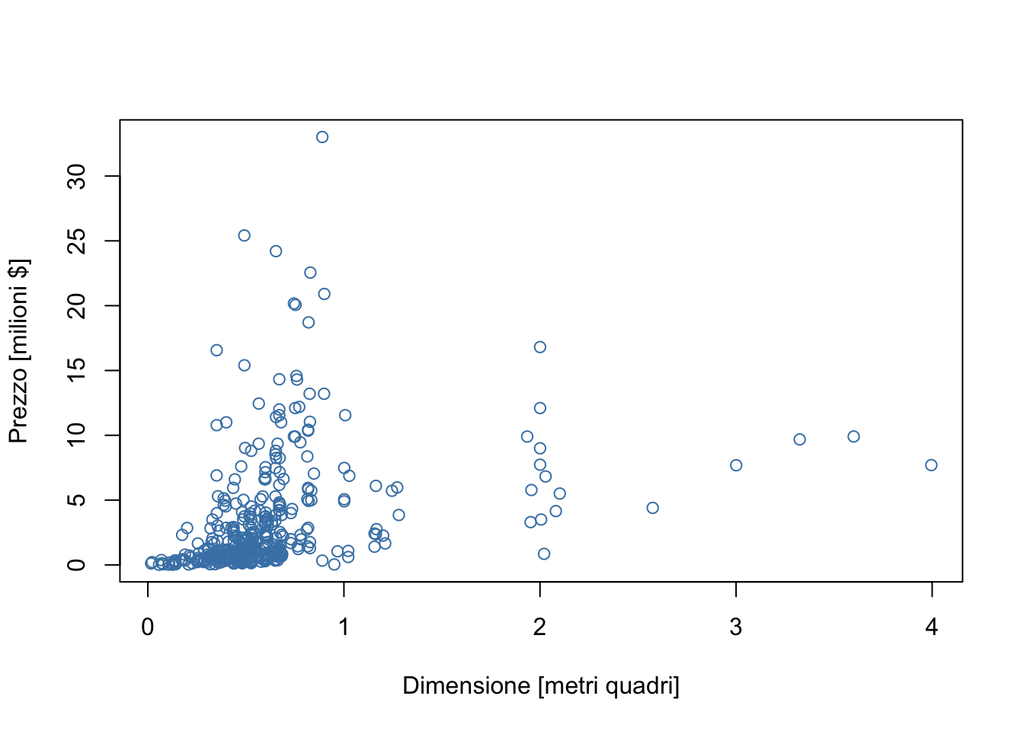

```r
monet$area <- with(monet, height * width)
plot(price ~ area, data = monet, col = "steelblue", xlab = "Dimensione [metri quadri]", ylab = "Prezzo [milioni $]")
```

Vista l’asimmetria della distribuzione dei prezzi di vendita, consideriamo anche il grafico di dispersione su scala logaritmica:

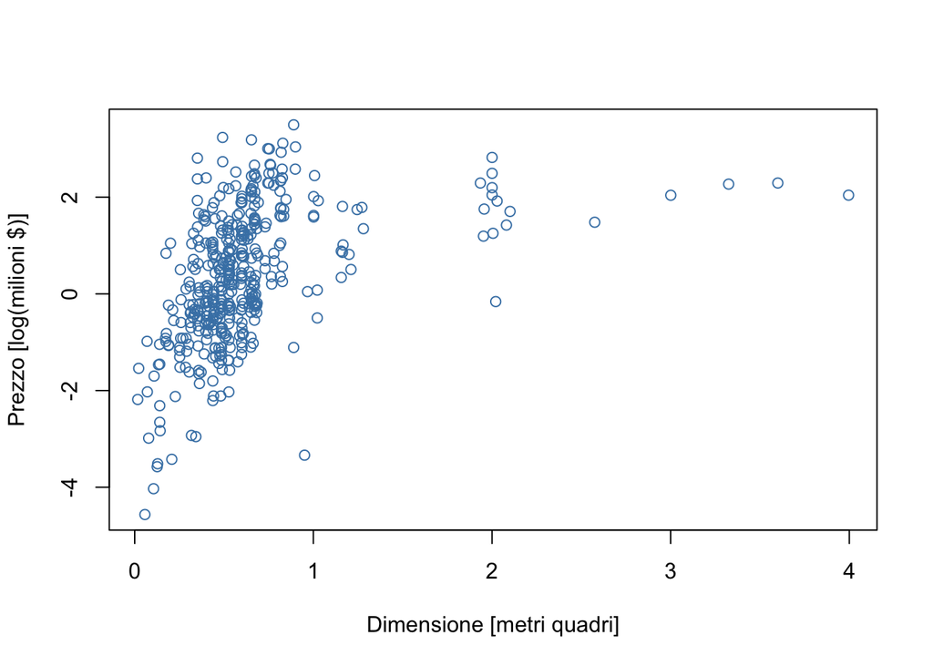

```r
plot(log(price) ~ area, data = monet, col = "steelblue", xlab = "Dimensione [metri quadri]", ylab = "Prezzo [log(milioni $)]")
```

La relazione fra prezzo di vendita e dimensione non sembra molto chiara. Proviamo a disegnare con due colori diversi i punti nel grafico di dispersione a seconda se i dipinti siano firmati:

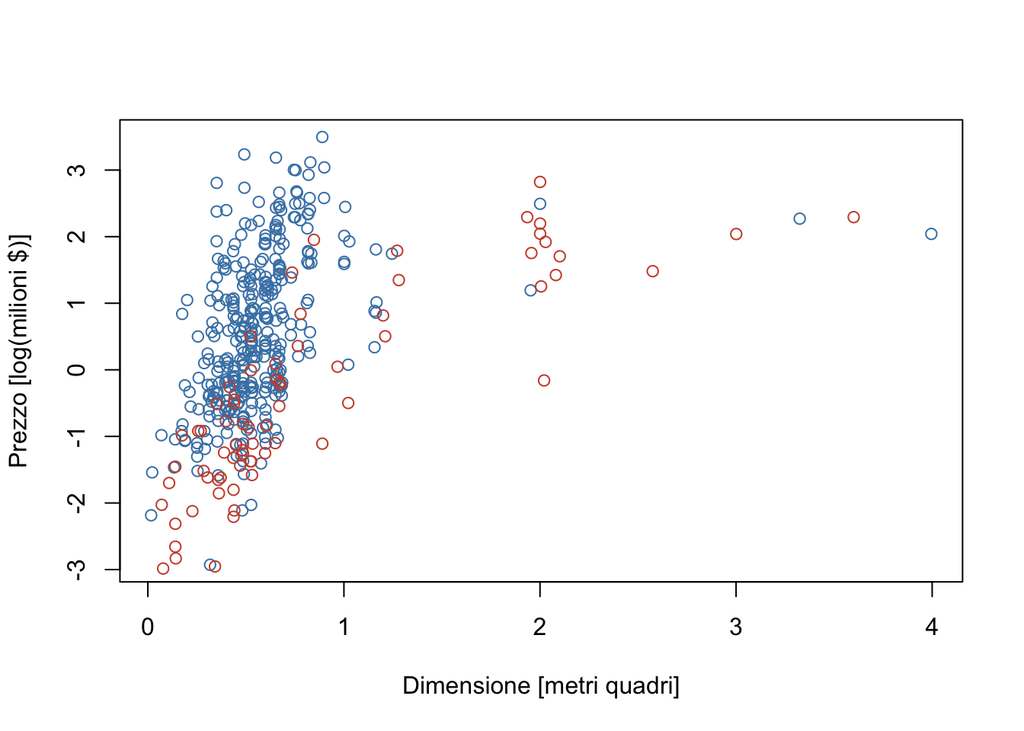

```r
## disegniamo prima i dipinti firmati
plot(log(price) ~ area, data = monet, subset = (signed == "Sì"), col = "steelblue",  xlab = "Dimensione [metri quadri]", ylab = "Prezzo [log(milioni $)]")
## e ora aggiungiamo i dipinti non firmati
points(log(price) ~ area, data = monet, subset = (signed == "No"), col = "tomato3")
```

In modo forse più efficace, possiamo disegnare due grafici di dispersione appaiati per i dipinti firmati e non firmati:

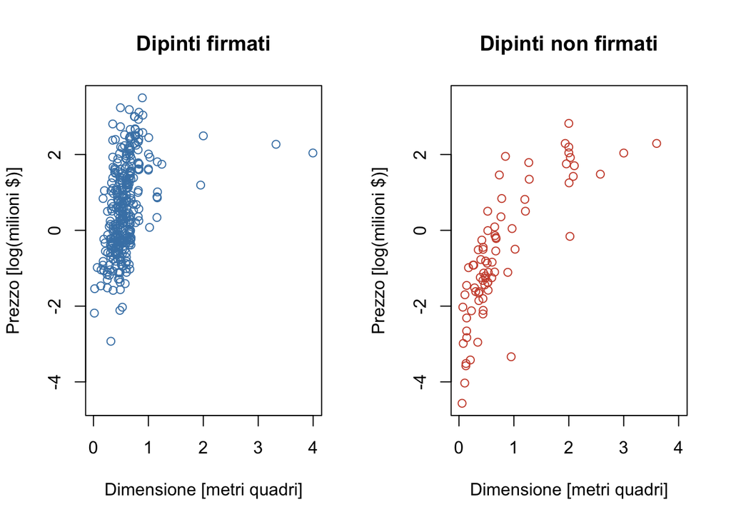

```r
## dividiamo la finestra grafica in due parti
par(mfrow = c(1, 2))
## dipinti firmati
plot(log(price) ~ area, data = monet, subset = (signed == "Sì"), col = "steelblue", main = "Dipinti firmati", xlab = "Dimensione [metri quadri]", ylab = "Prezzo [log(milioni $)]", ylim = range(log(price)), xlim = range(area))
## dipinti non firmati
plot(log(price) ~ area, data = monet, subset = (signed == "No"), col = "tomato3",
main = "Dipinti non firmati", xlab = "Dimensione [metri quadri]", ylab = "Prezzo [log(milioni $)]", ylim = range(log(price)), xlim = range(area))
```

I grafici distinti a seconda della presenza della firma, mostrano che la crescita del prezzo su scala logaritmica è approssimativamente lineare fino ad una dimensione di circa un metro quadri, con un tasso di crescita più rapido per i dipinti firmati.

Infine, valutiamo la relazione fra il prezzo di vendita e la casa d’aste. La variabile `house` è codificata come una variabile numerica, come si vede dal risultato della funzione `summary`:

```r
summary(monet$house)
```

```
##    Min. 1st Qu.  Median    Mean 3rd Qu.    Max.
##   1.000   1.000   2.000   1.612   2.000   3.000
```

Conviene trasformare la variabile `house` in una variabile categoriale:

```r
monet$house <- factor(monet$house)
summary(monet$house)
```

```
##   1   2   3
## 191 215  24
```

Inoltre, può essere preferibile indicare le case d’aste con delle lettere:

```r
levels(monet$house) <- c("A", "B", "C")
summary(monet$house)
```

```
##   A   B   C
## 191 215  24
```

La distribuzione di frequenza relativa mostra che le prime due case d’aste hanno una proporzione simile di dipinti venduti, mentre la terza casa d’aste ha poco più del 5% dei dipinti:

```r
table(monet$house)
```

```
##
##   A   B   C
## 191 215  24
```

```r
prop.table(table(monet$house))
```

```
##
##          A          B          C
## 0.44418605 0.50000000 0.05581395
```

```r
signif(prop.table(table(monet$house)), digits = 2)
```

```
##
##     A     B     C
## 0.440 0.500 0.056
```

Vediamo ora la distribuzione del prezzo di vendita condizionatamente alla casa d’aste:

```r
with(monet, by(price, house, summary))
```

```
## house: A
##     Min.  1st Qu.   Median     Mean  3rd Qu.     Max.
##  0.05054  0.71925  1.46350  3.05358  4.01994 22.55250
## ------------------------------------------------------------
## house: B
##     Min.  1st Qu.   Median     Mean  3rd Qu.     Max.
##  0.05351  0.59627  1.33126  3.35765  4.11525 33.01350
## ------------------------------------------------------------
## house: C
##    Min. 1st Qu.  Median    Mean 3rd Qu.    Max.
## 0.01041 0.05306 0.33205 0.98208 1.16747 6.60250
```

Le distribuzioni condizionate indicano che le prime due case d’aste hanno venduto dipinti a prezzi relativamente simili, mentre la terza casa d’aste ha venduto dipinti a prezzi medi nettamente inferiori, come si può visualizzare nei boxplot appaiati:

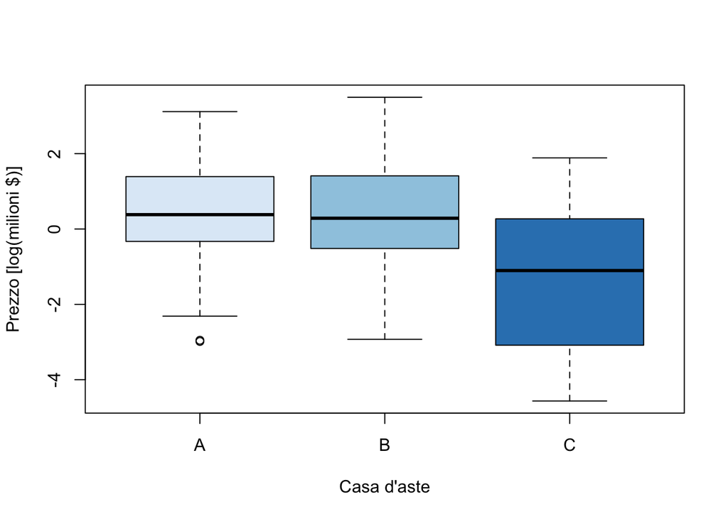

```r
with(monet, boxplot(log(price) ~ house, col = brewer.pal(3, "Blues"), ylab = "Prezzo [log(milioni $)]", xlab = "Casa d'aste"))
```

[^1]: Dati provenienti dal testo *Jank, W. (2011)*. Business Analytics for Managers. Springer}.